# Trader_Clustering_Bigger

## Polymarket: Structural Asymmetry in Trader Behavior

We identify that *trader_1* is the platform's automated market maker (AMM), executing trades via the LMSR pricing rule. It never posts limit orders. It reacts passively, with infinite inventory, and sets prices based on outstanding positions: $$ P_i = \frac{\exp(q_i / b)}{\sum_j \exp(q_j / b)} $$

This means most traders are not interacting in a true peer-to-peer market—they’re trading against a central agent with structural advantage.

Clustering trader behavior across games to understand how individuals interact with the AMM, including:

- **Who takes liquidity from the AMM**
- **Timing patterns (early vs. end-of-life trading)**
- **Exposure to edge capture via the curve**

Characterize behavioral profiles in a market dominated by a non-neutral counterparty. $$ \begin{array}{|c|l|} \hline \textbf{Cluster} & \textbf{Label and Description} \\ \hline 0 & \textbf{Strategic Passive Anchors}:\ \text{High maker ratio, large but stable trades, low AMM interaction, early activity, stable positions} \\ \hline 1 & \textbf{Liquidity Consumers}:\ \text{Moderate trading, high AMM dependence, balanced maker/taker, engages near end of life} \\ \hline 2 & \textbf{High-Impact Whales}:\ \text{Few but massive trades, high volatility, often hits price extremes, short-lived participation} \\ \hline 3 & \textbf{HFT-Style Liquidity Providers}:\ \text{Thousands of tiny trades, very bursty, high turnover, continuous presence, avoids extremes} \\ \hline \end{array} $$

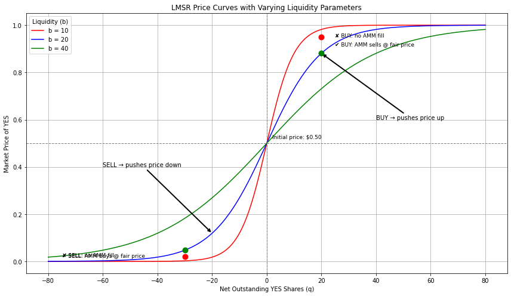

## How the AMM Makes Money: LMSR Explained

Polymarket's AMM uses a **Logarithmic Market Scoring Rule (LMSR)** to price shares dynamically based on trader demand. The AMM adjusts prices according to a convex cost function that guarantees liquidity and caps worst-case loss.

Let $q_i$ be the number of outstanding shares on outcome $i$. The LMSR cost function is:

$$ C(\mathbf{q}) = b \cdot \log\left( \sum_{i=1}^n \exp\left( \frac{q_i}{b} \right) \right) $$

where:

- $\mathbf{q} = (q_1, \dots, q_n)$ is the vector of shares,
- $b > 0$ is the liquidity parameter (higher $b$ = deeper book).

The **price** for outcome $i$ is the gradient of the cost function:

$$ p_i = \frac{\partial C}{\partial q_i} = \frac{\exp\left( \frac{q_i}{b} \right)}{\sum_{j=1}^n \exp\left( \frac{q_j}{b} \right)} $$

### Profit Mechanism

The AMM's revenue is the **total amount paid in** by traders (via $C(\mathbf{q}_{\text{final}}) - C(\mathbf{q}_{\text{initial}})$), while its **payout** is determined by the outcome.

Let the true outcome be $k$. Then the AMM pays out $q_k$ shares at $1$ each. The profit is:

$$ \text{Profit} = C(\mathbf{q}_{\text{final}}) - C(\mathbf{0}) - q_k $$

Because prices are always slightly worse for the trader than the expected value under full information, the AMM **makes money when traders are wrong or impatient**.

### Interpretation

- Traders push $q_i$ up by buying shares, increasing $C(\mathbf{q})$.
- When outcome $i$ doesn't happen, those shares are worthless.
- Thus, **bad forecasts fund the AMM’s profit**.

This mechanism works without ever posting limit orders. The AMM simply offers **take-it-or-leave-it prices** derived from the curve above.

## When Does the AMM Take the Trade?

In a Central Limit Order Book (CLOB), a trade occurs between:

- A **maker** (who posts a standing order), and
- A **taker** (who hits that order with a market/IOC order).

Polymarket has both:

- **User-posted limit orders** (via the CLOB)
- **An AMM** that provides standing liquidity, priced via LMSR.

The AMM **only acts as taker**, meaning it reacts to standing offers when they're **better than its LMSR price**.

### Example 1: AMM Gets the Trade (Taker)

- AMM LMSR price: \$0.60 for YES
- A trader posts a **limit sell** of YES at \$0.55
- \$0.55 is cheaper than \$0.60 → **AMM buys** from the trader

**Result:** Trader gives up value, AMM profits

### Example 2: AMM Doesn't Get the Trade

- AMM LMSR price: \$0.60 for YES
- Trader posts a **limit sell** at \$0.62
- AMM would not buy at that price → trade waits in the book

**Result:** Another trader might fill it, or it remains unfilled

### General Rule:

The AMM **only trades when**: $$ \text{Standing price} \leq \text{LMSR price} \quad \text{(for buys)} $$ $$ \text{Standing price} \geq \text{LMSR price} \quad \text{(for sells)} $$

It always posts prices via the **LMSR curve**, but **does not queue** into the book. So:

- You **can beat the AMM** by posting tighter prices
- You **can't front-run** the AMM — it reacts instantly when price improves

### Takeaway

- The AMM earns edge when traders give it good prices
- Otherwise, traders trade among themselves
- You can analyze this by tagging trades:
  - `maker == 'trader_1' or taker == 'trader_1'` → AMM involvement

## Layman’s Explanation of LMSR (Logarithmic Market Scoring Rule)

The LMSR is the rule used by the AMM (automated market maker) to set prices. It’s designed to **always give you a price**, no matter what, while protecting itself from unlimited loss.

### Imagine This

You’re running a prediction market where people bet on whether **YES** or **NO** will happen.

Every time someone buys a share of YES, the AMM:

- Increases the price of YES
- Decreases the price of NO
- Updates both prices based on how many shares of each have been bought

### The Math Behind It

The AMM tracks how many shares have been bought:

- $q_{\text{YES}}$: total YES shares bought
- $q_{\text{NO}}$: total NO shares bought

The **cost function** is:

$$ C(q_{\text{YES}}, q_{\text{NO}}) = b \cdot \log\left( e^{q_{\text{YES}}/b} + e^{q_{\text{NO}}/b} \right) $$

Where:

- $b$ is a constant that controls liquidity (higher $b$ = more liquidity, slower price movement)

The **price of YES** is the **instantaneous cost to buy one more YES share**:

$$ p_{\text{YES}} = \frac{e^{q_{\text{YES}}/b}}{e^{q_{\text{YES}}/b} + e^{q_{\text{NO}}/b}} $$

This means:

- If people buy lots of YES → price of YES rises
- If they buy NO → price of NO rises

### Key Intuition

1. **You pay more** the more you buy — price goes up with demand.
2. **You can always trade**, but large trades are expensive.
3. **Only one side pays out**, so the AMM makes money if the public is wrong.

### Example

- At the start: 0 shares bought → price = 50%
- If someone buys 100 YES shares:
  - $q_{\text{YES}}$ increases
  - Price rises to maybe 65%
- If YES ends up being correct, the AMM pays out \$1 per YES share
- If NO wins, it pays nothing → **AMM keeps the money paid in**

### Takeaway

LMSR is like a curve:

- **Smooth**, no gaps
- Always liquid
- Becomes steeper as more shares are bought

It’s mathematically elegant and financially safe — traders can’t bankrupt the AMM.

Standardized Feature Summary

|  | min | 25% | 50% | 75% | max |
| --- | --- | --- | --- | --- | --- |
| num_trades | -0.436282 | -0.400040 | -0.334060 | -0.082222 | 5.467503 |
| avg_trade_size | -0.938858 | -0.617241 | -0.203873 | 0.084607 | 4.630322 |
| max_trade_size | -0.520048 | -0.415307 | -0.344029 | 0.020705 | 6.008679 |
| volatility_of_size | -0.717650 | -0.532715 | -0.332213 | 0.057895 | 5.785740 |
| taker_ratio | -2.572887 | -0.584695 | 0.055960 | 0.674526 | 1.701875 |
| maker_ratio | -1.701875 | -0.674526 | -0.055960 | 0.584695 | 2.572887 |
| mean_time_between_trades | -0.932377 | -0.669572 | -0.287561 | 0.105252 | 5.051868 |
| burstiness | -1.679560 | -0.696133 | -0.279631 | 0.558147 | 3.334132 |
| amm_counterparty_ratio | -1.919440 | -0.793841 | -0.054657 | 0.573818 | 2.449451 |
| amm_volume_share | -2.233818 | -0.726480 | 0.077517 | 0.765205 | 1.678855 |
| trading_days_active | -1.388477 | -0.593589 | -0.217063 | 0.075790 | 3.380850 |
| position_turnover | -0.820121 | -0.820121 | -0.305374 | 0.370231 | 4.709257 |
| early_trade_ratio | -2.141933 | -0.730116 | -0.125944 | 0.795792 | 1.986327 |
| end_of_life_activity | -2.298588 | -0.610587 | -0.053980 | 0.698409 | 2.583032 |
| price_extremes_engaged | -0.830196 | -0.784041 | -0.386524 | 0.536651 | 2.796014 |

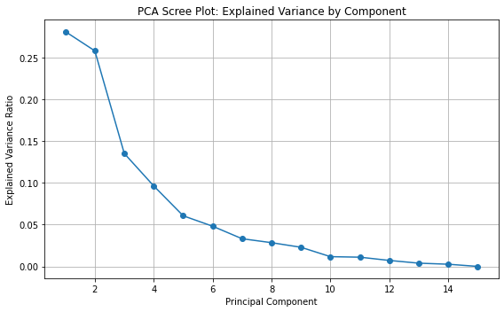

```
PC1: 0.281 cumulative explained variance
PC2: 0.539 cumulative explained variance
PC3: 0.674 cumulative explained variance
PC4: 0.771 cumulative explained variance
PC5: 0.831 cumulative explained variance
PC6: 0.879 cumulative explained variance
PC7: 0.912 cumulative explained variance
PC8: 0.941 cumulative explained variance
PC9: 0.964 cumulative explained variance
PC10: 0.975 cumulative explained variance
PC11: 0.986 cumulative explained variance
PC12: 0.994 cumulative explained variance
PC13: 0.997 cumulative explained variance
PC14: 1.000 cumulative explained variance
PC15: 1.000 cumulative explained variance
```

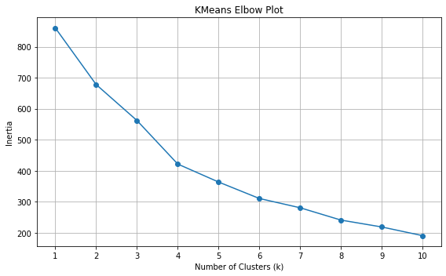

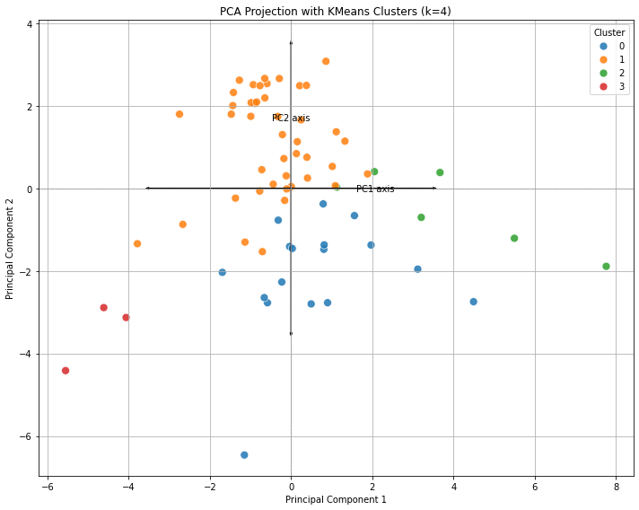

Cluster Profile Summary

| cluster | 0 | 1 | 2 | 3 |
| --- | --- | --- | --- | --- |
| num_trades | 733.760000 | 304.260000 | 351.500000 | 3876.000000 |
| avg_trade_size | 953.700000 | 924.770000 | 3820.880000 | 92.740000 |
| max_trade_size | 13655.110000 | 9087.420000 | 116085.080000 | 827.940000 |
| volatility_of_size | 1294.450000 | 924.720000 | 6949.680000 | 74.940000 |
| taker_ratio | 0.250000 | 0.550000 | 0.430000 | 0.320000 |
| maker_ratio | 0.750000 | 0.450000 | 0.570000 | 0.680000 |
| mean_time_between_trades | 1244.250000 | 1363.380000 | 489.050000 | 1482.740000 |
| burstiness | 1.630000 | 1.470000 | 1.780000 | 3.570000 |
| amm_counterparty_ratio | 0.080000 | 0.240000 | 0.120000 | 0.220000 |
| amm_volume_share | 0.110000 | 0.330000 | 0.270000 | 0.260000 |
| trading_days_active | 40.710000 | 31.580000 | 21.330000 | 106.330000 |
| position_turnover | 0.100000 | 0.160000 | 0.180000 | 0.710000 |
| early_trade_ratio | 0.310000 | 0.280000 | 0.300000 | 0.160000 |
| end_of_life_activity | 0.270000 | 0.290000 | 0.180000 | 0.460000 |
| price_extremes_engaged | 0.290000 | 0.190000 | 0.420000 | 0.000000 |

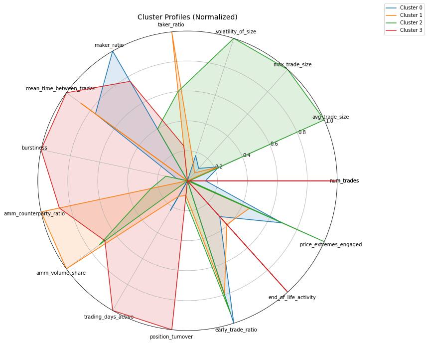

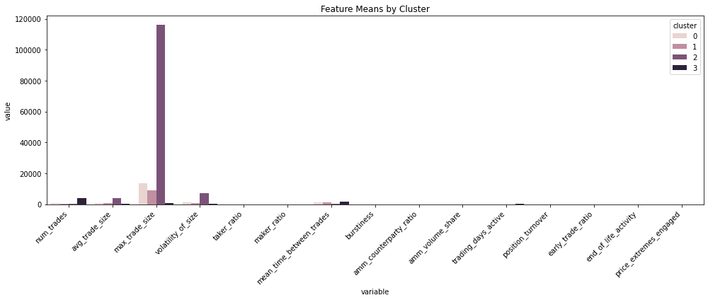

$$ \begin{array}{|c|l|} \hline \textbf{Cluster} & \textbf{Label and Description} \\ \hline 0 & \textbf{Strategic Passive Anchors}:\ \text{High maker ratio, large but stable trades, low AMM interaction, early activity, stable positions} \\ \hline 1 & \textbf{Liquidity Consumers}:\ \text{Moderate trading, high AMM dependence, balanced maker/taker, engages near end of life} \\ \hline 2 & \textbf{High-Impact Whales}:\ \text{Few but massive trades, high volatility, often hits price extremes, short-lived participation} \\ \hline 3 & \textbf{HFT-Style Liquidity Providers}:\ \text{Thousands of tiny trades, very bursty, high turnover, continuous presence, avoids extremes} \\ \hline \end{array} $$